# Who knows more? Socioeconomic-related inequality in knowledge about HIV in Malawi among Women, aged 15-49.

Tiwonge Chimpandule

07th August 2023

```r
##~~~~~~~~~~~~~~~~~~~~~~~~~~~~~~~~~~~~~~~~~~~~~~~~~~~~~~~~~~~~~~~~~~~~~~~~~~~~~~
## Packages ----
##~~~~~~~~~~~~~~~~~~~~~~~~~~~~~~~~~~~~~~~~~~~~~~~~~~~~~~~~~~~~~~~~~~~~~~~~~~~~~~

if(!require(pacman)) install.packages("pacman")
pacman::p_load(
  janitor,
  here,
  haven,
  scales,
  ggstatsplot,
  patchwork,
  tidyverse,
  flextable,
  crosstable,
  forcats
)
```

# Introduction

Proper understanding of HIV is crucial in preventing the spread of HIV and AIDS. This report presents findings from the 2016 Malawi Health and Demographic Survey, focusing on HIV-related knowledge among women aged 15-49. The report addresses the primary areas of concern identified in the literature

# Variables

## Explanatory variables

From review, the following explanatory variables were included:

- [Age](https://dhsprogram.com/pubs/pdf/dhsg4/recode6_dhs_22march2013_dhsg4.pdf)
- [Rerigion](https://www.idhsdata.org/idhs-action/variables/RELIGION#codes_section)
- [Ethinicity](https://dhsprogram.com/pubs/pdf/dhsg4/recode6_dhs_22march2013_dhsg4.pdf)
- [Highest education](https://dhsprogram.com/pubs/pdf/dhsg4/recode6_dhs_22march2013_dhsg4.pdf)
- [Wealth index](https://dhsprogram.com/topics/wealth-index/)
- [Marital status](https://dhsprogram.com/data/Guide-to-DHS-Statistics/Current_Marital_Status.htm)

```r
#~~~~~~~~~~~~~~~~~~~~~~~~~~~~~~~~~~~~~~~~~~~~~~~~~~~~~~~~~~~~~~~~~~~~~~~~~~~~~~
# Import and process data  ----
#~~~~~~~~~~~~~~~~~~~~~~~~~~~~~~~~~~~~~~~~~~~~~~~~~~~~~~~~~~~~~~~~~~~~~~~~~~~~~~

# Import the data and select the variables of interest
mw_hiv_raw <- haven::read_dta(
  here("data/MWIR7AFL.DTA"),
  col_select = c(
    caseid,
    v130,
    v131,
    v106,
    v101,
    v131,
    v190,
    v501,
    v020,
    v012,
    v013,
    v754dp,
    v756,
    v754wp,
    v754jp,
    v823,
    v754cp
  )
)

mw_hiv_raw  <- mw_hiv_raw  %>%
  rename(
    Religion = v130,
    Ethnicity = v131,
    Highest_educational_level = v106,
    Region = v101,
    Wealth_index_combined = v190,
    Current_marital_status = v501,
    Ever_married_sample = v020,
    Respondents_current_age = v012,
    Age_in_5_year_groups = v013,
    Reduce_risk_getting_HIV_one_sex_partner_only_no_other_partners = v754dp,
    Healthy_looking_person_can_have_HIV = v756,
    Can_get_HIV_by_sharing_food_with_person_who_has_AIDS = v754wp,
    Can_get_HIV_from_mosquito_bites = v754jp,
    Can_get_HIV_by_witchcraft_or_supernatural_means = v823,
    Reduce_risk_getting_HIV_always_use_condoms_during_sex = v754cp
  )

# Simplifying education categories
mw_hiv_raw  <- mw_hiv_raw  %>%
  haven::as_factor()



# Create a depedent variable for HIV knowledge
mw_hiv_raw <- mw_hiv_raw %>%
  mutate(
    HIV_knowledge = case_when(
      Reduce_risk_getting_HIV_always_use_condoms_during_sex == "yes" &
        Reduce_risk_getting_HIV_one_sex_partner_only_no_other_partners == "yes" &
        Healthy_looking_person_can_have_HIV == "yes" &
        (Can_get_HIV_from_mosquito_bites == "no" | Can_get_HIV_by_witchcraft_or_supernatural_means == "no") ~ "Yes",
      TRUE ~ "No"
    ),
    HIV_knowledge = as.factor(HIV_knowledge)
  )



# Total number of respondents
mw_hiv_raw <- mw_hiv_raw %>%
  mutate(total_unique_respondents = format(n_distinct(caseid), big.mark = ",", scientific = FALSE))

# Print the first few rows to check the result
head(mw_hiv_raw)
```

```
## # A tibble: 6 × 18
##   caseid  Respondents_current_…¹ Age_in_5_year_groups Ever_married_sample Region
##   <chr>                    <dbl> <fct>                <fct>               <fct>
## 1 "     …                     30 30-34                all woman sample    centr…
## 2 "     …                     30 30-34                all woman sample    centr…
## 3 "     …                     28 25-29                all woman sample    centr…
## 4 "     …                     30 30-34                all woman sample    centr…
## 5 "     …                     16 15-19                all woman sample    centr…
## 6 "     …                     36 35-39                all woman sample    centr…
## # ℹ abbreviated name: ¹Respondents_current_age
## # ℹ 13 more variables: Highest_educational_level <fct>, Religion <fct>,
## #   Ethnicity <fct>, Wealth_index_combined <fct>, Current_marital_status <fct>,
## #   Reduce_risk_getting_HIV_always_use_condoms_during_sex <fct>,
## #   Reduce_risk_getting_HIV_one_sex_partner_only_no_other_partners <fct>,
## #   Can_get_HIV_from_mosquito_bites <fct>,
## #   Can_get_HIV_by_sharing_food_with_person_who_has_AIDS <fct>, …
```

```r
# Mean and medianage
mw_hiv_raw <- mw_hiv_raw %>%
  mutate(
    mean_age = round(mean(Respondents_current_age, na.rm = TRUE),0),
    median_age = round(median(Respondents_current_age, na.rm = TRUE),0)
  )
```

```r
##~~~~~~~~~~~~~~~~~~~~~~~~~~~~~~~~~~~~~~~~~~~~~~~~~~~~~~~~~~~~~~~~~~~~~~~~~~~~~~
## Charts ----
##~~~~~~~~~~~~~~~~~~~~~~~~~~~~~~~~~~~~~~~~~~~~~~~~~~~~~~~~~~~~~~~~~~~~~~~~~~~~~~

# Population myramid of respondents
# Calculate the counts by age group and HIV knowledge
pop_pyramid_data <- mw_hiv_raw %>%
  group_by(Age_in_5_year_groups, HIV_knowledge) %>%
  summarise(count = n()) %>%
  ungroup() %>%
  mutate(HIV_knowledge = ifelse(HIV_knowledge == "Yes", "Yes", "No")) %>%
  mutate(count = ifelse(HIV_knowledge == "No", -count, count))

max_count <- max(abs(pop_pyramid_data$count))

# Create the population pyramid
pop_pyramid_plot <- ggplot(pop_pyramid_data, aes(x = Age_in_5_year_groups, y = count, fill = HIV_knowledge)) +
  geom_bar(stat="identity", position = 'identity') +
  coord_flip() +
  theme_minimal() +
  scale_y_continuous(labels = abs, limits = c(-max_count, max_count)) +
  labs(title = "Distribution of women respondents in the survey,n= 24,562",
       x = "Age Group",
       y = "Number of respondents",
       fill = "HIV Knowledge") +
  theme(legend.position = "bottom")


# Chart 1: A box plot of the age distribution by HIV knowledge----
p1 <- ggplot(data = mw_hiv_raw, aes(x = HIV_knowledge, y = Respondents_current_age, fill = HIV_knowledge)) +
  geom_boxplot() +
  labs(title = "Age Distribution by HIV Knowledge", x = "HIV Knowledge", y = "Age", fill = "HIV Knowledge") +
  theme_minimal()



# Chart 2 :Knowledge of HIV Distribution----

# Summarizing the data
knowledge_status_summary <- mw_hiv_raw %>%
  group_by(HIV_knowledge) %>%
  summarise(count = n()) %>%
  mutate(percentage = count/sum(count))


p2 <-
  ggplot(knowledge_status_summary,
         aes(x = HIV_knowledge, y = count, fill = HIV_knowledge)) +
  geom_bar(stat = "identity") +
  geom_text(aes(label = scales::comma(count, accuracy = 1)), vjust = -0.1) +  # Formatting with comma here
  geom_text(aes(label = paste0(round(percentage * 100, 1), "%")), vjust = 1.3) +
  labs(title = "Knowledge of HIV Status Among 24,562 women respondents (15-49)", y = "Number of Respondents") +
  theme_minimal() +
  theme(legend.position = "none")


# Chart 3+ : Distribution of Respondents who had knowledge of HIV----
# List of categories
categories <- c("Region", "Highest_educational_level", "Religion", "Ethnicity", "Wealth_index_combined", "Current_marital_status")

# Create an empty list to store plots
plots_list <- list()

# Generate plots for each category and store them in the list
for (category in categories) {
  combined_chart_data <- mw_hiv_raw %>%
    group_by(!!sym(category)) %>%
    summarise(count_yes = sum(HIV_knowledge == "Yes"),
              total = n(),
              percentage_yes = count_yes / total)

  p3 <- ggplot(combined_chart_data, aes(x = reorder(!!sym(category), -percentage_yes), y = percentage_yes, fill = !!sym(category))) +
    geom_bar(stat = "identity") +
    geom_text(aes(label = scales::percent(percentage_yes, accuracy = 1)), position = position_stack(vjust = 0.5), color = "white", fontface = "bold") +
    labs(title = paste("HIV Knowledge by", category),
         y = "% of respondents with HIV-Knowledge",
         x = "Respondent Category") +
    theme_minimal() +
    theme(legend.position = "none", axis.text.x = element_text(angle = 45, hjust = 1)) +
    scale_y_continuous(labels = scales::percent_format()) +
    expand_limits(y = c(min(combined_chart_data$percentage_yes), max(combined_chart_data$percentage_yes)))

  plots_list[[category]] <- p3
}


#~~~~~~~~~~~~~~~~~~~~~~~~~~~~~~~~~~~~~~~~~~~~~~~~~~~~~~~~~~~~~~~~~~~~~~~~~~~~~~
# table 1
#~~~~~~~~~~~~~~~~~~~~~~~~~~~~~~~~~~~~~~~~~~~~~~~~~~~~~~~~~~~~~~~~~~~~~~~~~~~~~~

# Create the cross-tabulation with count and percentages
cross_tab <- mw_hiv_raw %>%
  tabyl(Age_in_5_year_groups, HIV_knowledge) %>%
  adorn_percentages("row") %>%
  adorn_pct_formatting(digits = 0) %>%
  adorn_ns()

# Convert to a flextable
cross_tab_ft <- flextable::regulartable(cross_tab)

# Format the flextable
cross_tab_ft <- cross_tab_ft %>%
  flextable::set_caption("Table 1: Knowledge of HIV by wealth index") %>%
  flextable::theme_zebra() %>%
  flextable::align(align = "center", part = "all")
```

# Results

The study focused on the descriptive analysis to show the variation of HIV knowledge by different determinant

## Respondents in the survey

A total of 24,562 women, aged between 15 and 49, were surveyed about their HIV-related knowledge.

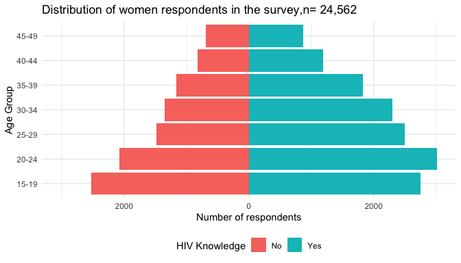

Figure 1: Age Distribution of surveyed women.

```r
pop_pyramid_plot
```

## Distribution of HIV-Related Knoweledge

```r
p1
```

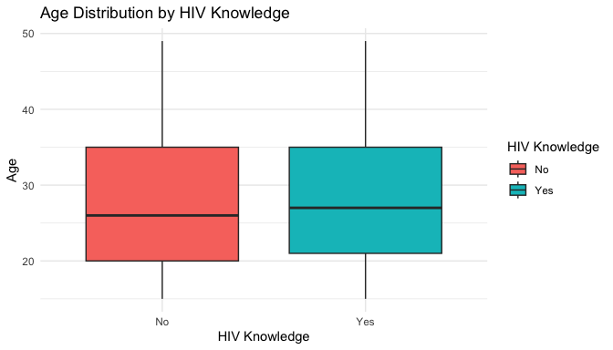

Figure 2: Box plot for HIV knowledge.

Table 1 below displays the distribution of the response variable across 5-year age groups. Among the surveyed women, adolescent girls aged 15-19 had the lowest knowledge of HIV at 52%, while women in the 24-29 and 30-34 year groups exhibited the highest knowledge at 63%

| Age_in_5_year_groups | No | Yes |
| --- | --- | --- |
| 15-19 | 48% (2526) | 52% (2747) |
| 20-24 | 41% (2078) | 59% (3016) |
| 25-29 | 37% (1483) | 63% (2493) |
| 30-34 | 37% (1353) | 63% (2295) |
| 35-39 | 39% (1163) | 61% (1825) |
| 40-44 | 41% (829) | 59% (1193) |
| 45-49 | 45% (695) | 55% (866) |

## How does HIV-related information vary by region?

Figure 3 below indicates that the Southern region had the highest prior HIV knowledge at 61%, while the Northern region recorded the lowest at 55%

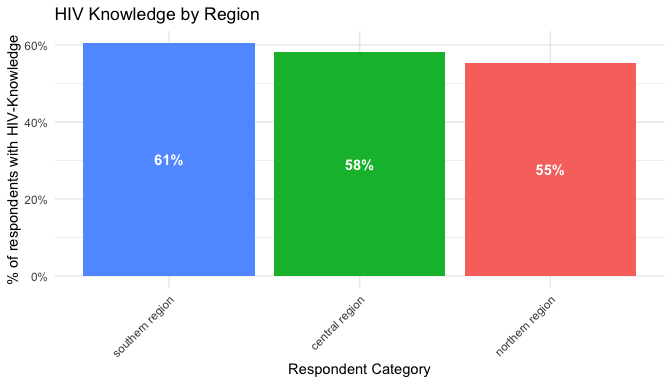

Figure 3: HIV Knowledge by Region.

```r
plots_list[["Region"]]
```

## How does HIV-related information vary by Highest education ?

Figure 4 below reveals that women with higher education had the highest prior HIV knowledge at 71%, whereas those with no education recorded the lowest at 49%.

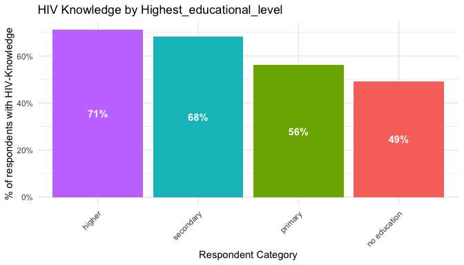

Figure 4: HIV Knowledge by Highest education level.

```r
plots_list[["Highest_educational_level"]]
```

## How does HIV-related information vary by religion?

Figure 5 below indicates that women who were Anglican had higher prior HIV knowledge, while women from other religions had a knowledge rate of 50%.

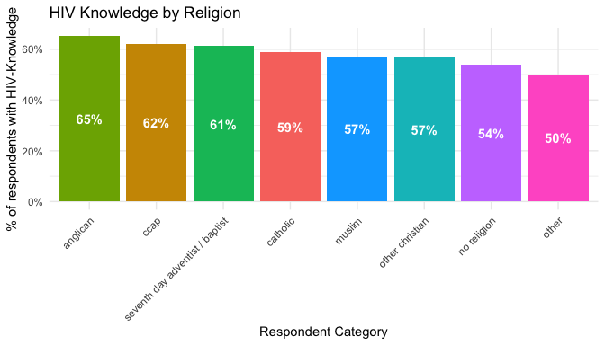

Figure 5:HIV Knowledge by Religion.

```r
plots_list[["Religion"]]
```

## How does HIV-related information vary by Ethnicity ?

Figure 6 below reveals that women of Nyanja ethnicity had a higher prior knowledge of HIV at 73%, whereas those from the Tumbuka ethnicity recorded a lower rate at 50%.

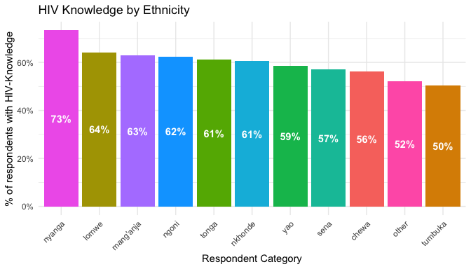

Figure 6: HIV Knowledge by Ethinicity.

```r
plots_list[["Ethnicity"]]
```

## How does HIV-related information vary by Wealth Index ?

Figure 7 below reveals that women from the rich wealth index had a higher prior knowledge of HIV at 66%, whereas those from the poorest wealth index recorded a lower rate at 51%.

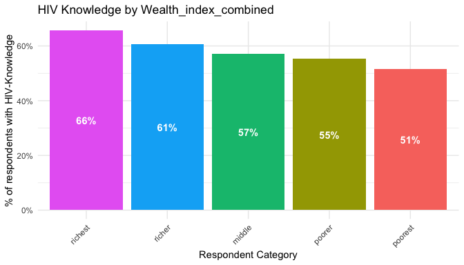

Figure 7: HIV Knowledge by Wealth Index.

```r
plots_list[["Wealth_index_combined"]]
```

## How does HIV-related information vary by Marital status ?

Figure 8 below reveals that widowed women had the highest knowledge at 61%, while those who were never in a union recorded a lower rate at 56%

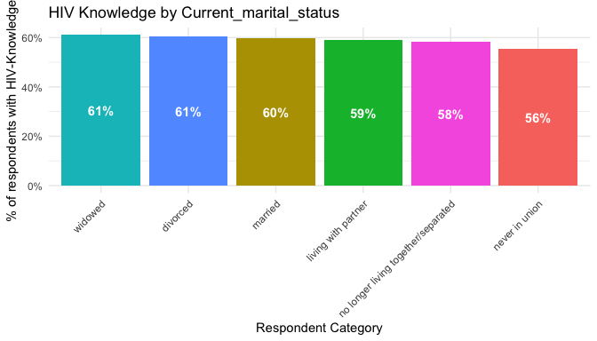

Figure 8: HIV Knowledge by Marital status.

```r
plots_list[["Current_marital_status"]]
```

# Conclusion

This descriptive analysis has revealed that comprehensive knowledge about HIV in Malawi varies across different determinants. A full inferential study should be undertaken to identify the factors that affect HIV knowledge in Malawi.